# Proyecto Grupal - Análisis de Datos I

# Librerías y carga de datos

Nota: El archivo autoreproducible es el main.rmd, en conjunto con todas las carpetas de proyecto.

```r
source("cod/r/setup.R")
```

```r
gen <- scrapW("genfiltrada")
```

# Gráficos

## Cantidad de mensajes por mes y año

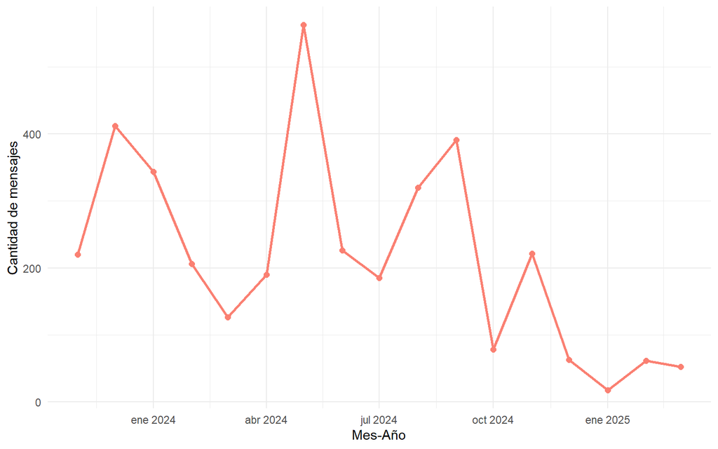

## Top de autores con más mensajes

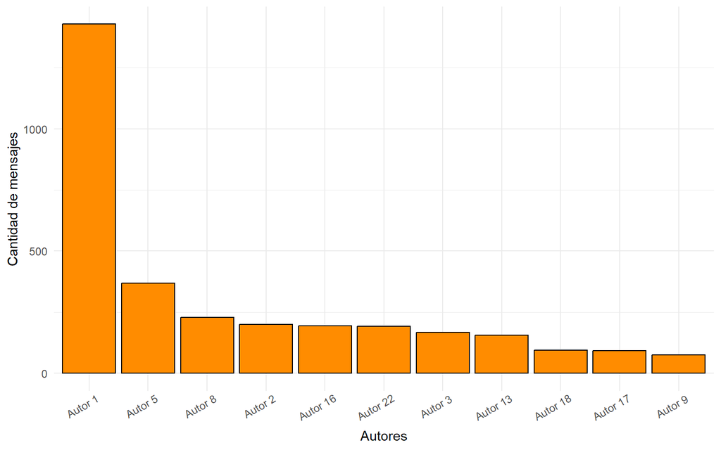

## Cantidad de mensajes por hora

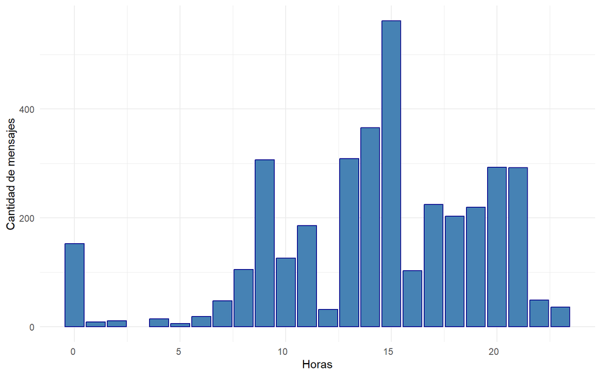

## Boxplot de cada autor

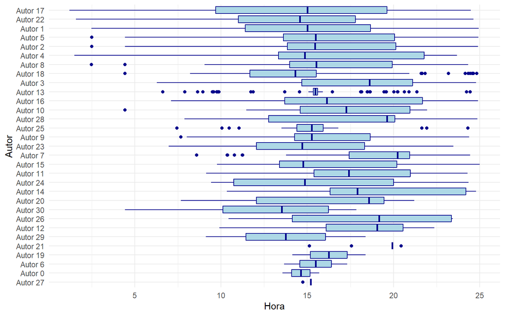

## Mayor cantidad de mensajes editados

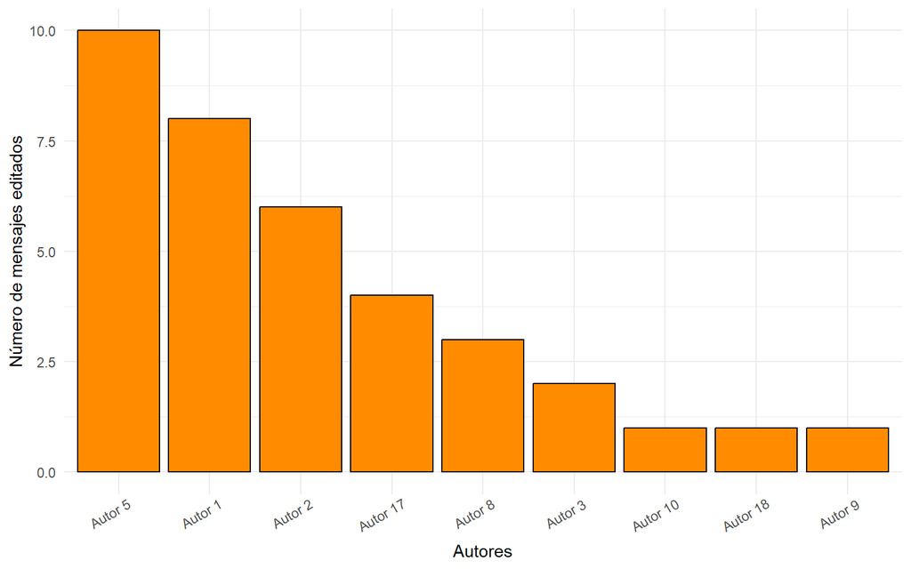

## Mapa de palabras

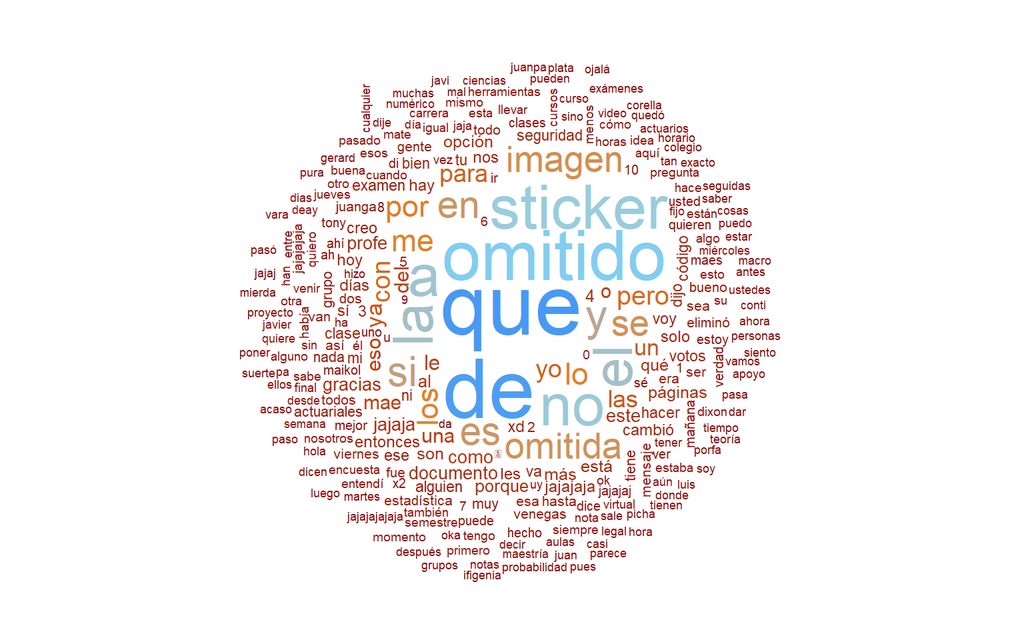

# Preparación para clusterización

Se hará un caso puro sin eliminación y el otro caso con selección ## Selección de mensajes significativos Los mensajes significativos serán todos aquellos que no tengan stickers, imágenes, documentos etc. Todos estos mensajes deberían ser completamente inútiles para un análisis, puesto que solo contienen eso.

```r
gen_c <- gen
gen_c$id <- 1:3675
copia <- gen_c %>%
  filter(!grepl("sticker omitido|imagen omitida|Se eliminó este mensaje|documento omitido|Cambió tu código de seguridad|Video omitido|añadió|https|usando el enlace de invitación|eliminó|cambió su número de teléfono", mensaje))
```

Se deciden eliminar los links puesto que después de una revisión manual son muy pocos los casos significativos

## Eliminación de encuestas

```r
copia <- copia %>%
  filter(!grepl("ENCUESTA:|OPCIÓN:", mensaje))
```

## Eliminación del autor de control de Whatsapp

```r
copia <- copia[copia$autor != 'Autor 0',]
```

## Tokenización de las palabras

```r
tokens <- copia %>%
  unnest_tokens(palabras, mensaje)
```

## Eliminación de las menciones (@numtelefono) y enteros

```r
tokens <- tokens %>%
  filter(!grepl("^\\d+$", palabras))
```

## Eliminación de palabras monótonas

```r
palabras <- copia$mensaje
mensajes_clean <- gsub("[[:punct:]]", "", tolower(palabras))
totales <- data.frame(palabras = unlist(strsplit(mensajes_clean, "\\s+")))
cuentas <- totales %>% count(palabras)
```

### Mapeo de palabras con eliminaciones

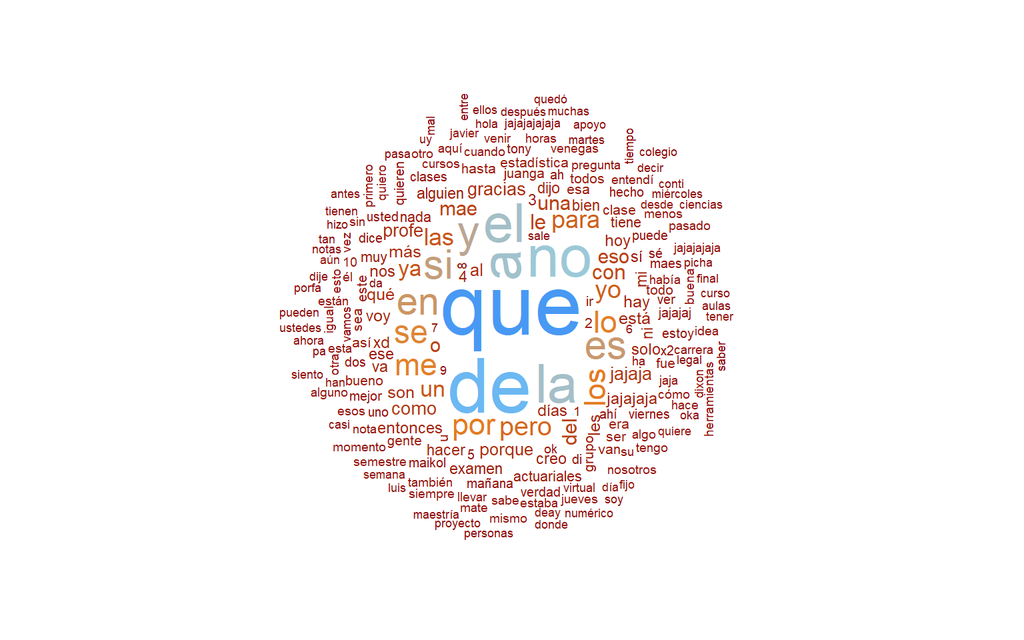

### Eliminación de palabras más repetidas sin sentimiento (43 veces o más)

```r
cuentas <- cuentas[cuentas$n >= 43,]
cuentas <- cuentas %>% mutate(get_nrc_sentiment(palabras, lang="spanish"))
```

```r
cuentas %>%
  summarise(across(3:ncol(.), sum, na.rm = TRUE))
```

```
##   anger anticipation disgust fear joy sadness surprise trust negative positive
## 1     0            0       0    0   0       0        0     0        0        0
```

Al no haber sentimientos, se pueden optar por remover en este caso.

```r
tokens <- tokens %>%
  anti_join(cuentas, by = "palabras")
```

### Visualización después de eliminación

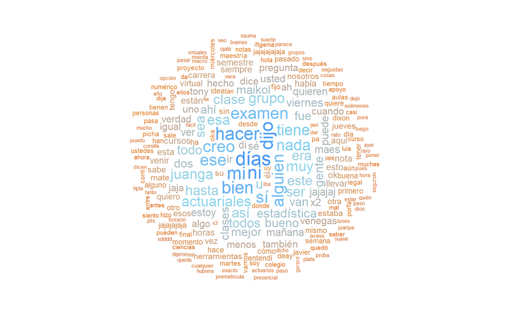

# Modelos

## Modelo original (sin eliminación)

```r
mdl_o <- gen_c %>%
  unnest_tokens(palabras, mensaje)
```

## Modelo filtrado (con eliminación)

Se puede notar una reducción de la mitad de las observaciones

```r
mdl_s <- tokens
```

## Sentimientos de los modelos

```r
t <- proc.time()
mdl_o <- mdl_o %>% mutate(get_nrc_sentiment(palabras, lang="spanish"))
mdl_s <- mdl_s %>% mutate(get_nrc_sentiment(palabras, lang="spanish"))
# proc.time() - t
```

## Sentimientos generales

```r
mdl_o %>%
  summarise(across(7:ncol(.), sum, na.rm = TRUE))
```

```
##   anger anticipation disgust fear joy sadness surprise trust negative positive
## 1   144          275     138  230 189     235      143   405      552      704
```

```r
mdl_s %>%
  summarise(across(7:ncol(.), sum, na.rm = TRUE))
```

```
##   anger anticipation disgust fear joy sadness surprise trust negative positive
## 1   139          246     138  225 161     230      132   361      532      665
```

## Agrupación por mensajes de nuevo

```r
mdl_o <- mdl_o %>%
  group_by(id) %>%
  summarise(across(anger:positive, sum), .groups = "drop")

mdl_s <- mdl_s %>%
  group_by(id) %>%
  summarise(across(anger:positive, sum), .groups = "drop")
```

```r
mdl_o <- inner_join(gen_c, mdl_o, by = join_by(id))
mdl_s <- inner_join(gen_c, mdl_s, by = join_by(id))
```

Hay menos mensajes en el original puesto que los emojis solos no se tokenizan.

## Eliminación de las variables no significativas (sin sentimientos)

Se procederá a dividir los modelos más, un lado sin los sentimientos en 0

```r
ind_o <- rowSums(mdl_o[,7:15] != 0) != 0
ind_s <- rowSums(mdl_s[,7:15] != 0) != 0
```

```r
mdl_1 <- mdl_o
mdl_2 <- mdl_s
mdl_3 <- mdl_o[ind_o,]
mdl_4 <- mdl_s[ind_s,]
```

# Clusterización por medio de métodos vistos en clase

## Funciones de clusterización

```r
colocar <- function(ind, centroids, past){
  dist <- sapply(1:nrow(centroids), function(x) sum((centroids[x,] - ind)^2))
  posibles <- which(dist == min(dist))
  if(length(posibles) == 1){
    return(posibles[1])
  } else if(sum(posibles == past) > 0){
    return(past)
  } else {
    return(posibles[1])
  }
}
```

### Kmeans

```r
kmeans <- function(nodes, df){
  len <- nrow(df)
  ids <- sample(len, nodes)
  val <- df[,7:16]
  centr <- val[ids,]
  clusters <- rep(0, len)
  clusters[ids] <- 1:nodes
  past <- clusters
  numiter <- 0
  while(numiter < 100){
    clusters <- sapply(1:len, function(x) colocar(val[x,],centr, past[x]))
    print(abs(sum(clusters!=past)))
    if(abs(sum(clusters!=past)) == 0){
      break
    } else{
      past <- clusters
    }
    numiter <- numiter + 1
    centr <- t(sapply(1:nodes, function(x)
      sapply(1:9, function (y) mean(val[clusters == x, y]))
    ))
  }
  return(list(clusters, centr))
}
```

### Kmedians

```r
kmedians <- function(nodes, df){
  len <- nrow(df)
  ids <- sample(len, nodes)
  val <- df[,7:16]
  centr <- val[ids,]
  clusters <- rep(0, len)
  clusters[ids] <- 1:nodes
  past <- clusters
  numiter <- 0
  while(numiter < 100){
    clusters <- sapply(1:len, function(x) colocar(val[x,],centr, past[x]))
    print(abs(sum(clusters!=past)))
    if(abs(sum(clusters!=past)) == 0){
      break
    } else{
      past <- clusters
    }
    numiter <- numiter + 1
    new_centr <- t(sapply(1:nodes, function(x)
      sapply(1:9, function (y) median(val[clusters == x, y]))
    ))
    new_centr <- sapply(1:nodes, function(x) colocar(new_centr[x,], val[clusters == x, ], 0))
    centr <- t(sapply(1:nodes, function(x) val[clusters == x, ][new_centr[x],]))
    ids <- sapply(1:nodes, function(x) df[clusters == x, 6][new_centr[x]])
  }
  return(list(clusters, centr, ids))
}
```

### Prueba de kmeans

```r
t <- proc.time()
clusters <- 5
clus_mean <- kmeans(clusters, mdl_4)
```

```
## [1] 635
## [1] 88
## [1] 30
## [1] 24
## [1] 15
## [1] 7
## [1] 4
## [1] 2
## [1] 3
## [1] 0
```

```r
proc.time() - t
```

```
##    user  system elapsed
##   24.56    0.42   25.47
```

### Resumen clusters

```r
sapply(1:clusters, function(x) colSums(mdl_4[clus_mean[[1]] == x,7:16]))
```

```
##              [,1] [,2] [,3] [,4] [,5]
## anger          74   13    0   52    0
## anticipation   31   56   34   26   99
## disgust        77    4    2   47    8
## fear           66   23    2  105   29
## joy             8   28   47   11   67
## sadness       141   25    1   56    7
## surprise       14   18   28   53   19
## trust          23   50   82   15  191
## negative      271   36    1  221    3
## positive       58   90  121   34  189
```

```r
sapply(1:clusters, function(x) sum(clus_mean[[1]] == x))
```

```
## [1] 227  25  44  81 263
```

### Prueba de kmedians

```r
t <- proc.time()
clus_median <- kmedians(5, mdl_4)
```

```
## [1] 635
## [1] 211
## [1] 12
## [1] 0
```

```r
proc.time() - t
```

```
##    user  system elapsed
##   10.81    0.26   11.34
```

De este se pueden sacar las observaciones que son centroides para su interpretación

```r
sapply(1:clusters, function(x) mdl_4[mdl_4$id == clus_median[[3]][x], 4])
```

```
## [1] "Pero esta vez cuenta con apoyo"
## [2] "No es como si hubiese hecho diferencia a 3 mintos del quizx"
## [3] "Nada que decir al respecto"
## [4] "Yo voy tarde"
## [5] "Que clase  más despiche"
```

### Paralelización de las funciones

Sirve para hacer simulaciones y encontrar el set de clusters más usado

```r
kmeans_par <- function(n, clst, mdl, cores) {
  cl <- makeCluster(cores)
  clusterExport(
    cl,
    varlist = c("clusters","mdl_1","mdl_2","mdl_3","mdl_4","kmeans","colocar"),
    envir = environment())
  resultados <- parSapply(cl, 1:n, function(x) kmeans(clst, mdl)[[2]])
  stopCluster(cl)
  return(resultados)
}
```

```r
kmedians_par <- function(n, clst, mdl, cores) {
  cl <- makeCluster(cores)
  clusterExport(
    cl,
    varlist = c("clusters","mdl_1","mdl_2","mdl_3","mdl_4","kmedians","colocar"),
    envir = environment())
  resultados <- parSapply(cl, 1:n, function(x) kmedians(clst, mdl)[[3]])
  stopCluster(cl)
  return(resultados)
}
```

### Prueba algoritmo

```r
# t <- proc.time()
# clusters <- 5
# res5 <- kmedians_par(1000, clusters, mdl_4, 6)
# proc.time() - t
# write.csv(res5, "res/res5.csv")
res5 <- read.csv("res/res5.csv") %>% select(-1)
```

### Obtener el set de centroides moda para kmedians

```r
centr <- t(sapply(data.frame(res5), function(x) sort(x)))
df <- apply(centr, 1, paste, collapse = "-")
tabla <- sort(table(df), decreasing = TRUE)
tabla[tabla>5]
```

```
## df
##   2-41-98-142-373 40-98-142-216-373  40-41-98-142-216  2-41-98-142-2062
##                 9                 9                 8                 7
##  2-41-98-216-2062   2-41-98-216-373 40-98-216-254-373   15-40-65-98-142
##                 7                 7                 7                 6
##  40-41-98-216-373
##                 6
```

### Obtener los centroides moda para kmedians

```r
tabla <- sort(table(unlist(res5)), decreasing = T)
tabla[tabla>100]
```

```
##
##   98   40    2  373  142   15  216 2062   41   99   43  355
##  861  539  494  342  317  241  229  214  205  181  113  106
```

### Recuperación de los clusters

```r
indices <- c(2,41,98,142,373)
centr <- t(sapply(1:5, function(x) mdl_4[mdl_4$id == indices[x], 7:16]))
clusters <- sapply(1:640, function(x) colocar(mdl_4[x,7:16], centr, 0))
```

```r
sapply(1:5, function(x) colSums(mdl_4[clusters == x,7:16]))
```

```
##              [,1] [,2] [,3] [,4] [,5]
## anger          23  104    0    0   12
## anticipation   24   29    4   57  132
## disgust        27   99    5    1    6
## fear           70  107    3   10   35
## joy             0    9    0    0  152
## sadness        98   97    1    5   29
## surprise       40   24    5    1   62
## trust          14   18  110    1  218
## negative      260  226    0    1   45
## positive       30   36   55   13  358
```

```r
sapply(1:5, function(x) sum(clusters == x))
```

```
## [1] 208  99 108  55 170
```

## Obtención de la clusterización óptima por medio del método del codo

```r
wcss <- function(nodes, df){
  res <- kmeans(i, df)
  points_c <- sapply(1:nodes, function(x) sum(res[[1]] == x))
  wcss <- sum(sapply(1:nodes, function(x) sum(sapply(
    1:points_c[x], function(y) sum((df[res[[1]] == x, 7:16][y,] - res[[2]][x,])^2)
  ))))
  return(wcss)
}
```

```r
# t <- proc.time()
# metrica <- data.frame(mdl1 = rep(0,10),
#                       mdl2 = rep(0,10),
#                       mdl3 = rep(0,10),
#                       mdl4 = rep(0,10))
# for(i in 1:10){
#   print(i)
#   metrica$mdl1[i] <- wcss(i, mdl_1)
#   metrica$mdl2[i] <- wcss(i, mdl_2)
#   metrica$mdl3[i] <- wcss(i, mdl_3)
#   metrica$mdl4[i] <- wcss(i, mdl_4)
# }
# proc.time() - t
# metrica$x <- 1:10
# metrica <- metrica %>%
#   pivot_longer(cols = starts_with("mdl"),
#                names_to = "modelo",
#                values_to = "valor")
# metrica_median <- metrica
# write.csv(metrica_median, "res/metrica_median.csv")
metrica_mean <- read.csv("res/metrica_mean.csv")
metrica_median <- read.csv("res/metrica_median.csv")
```

### Métrica para kmeans

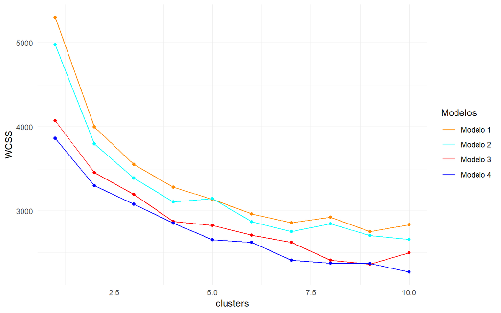

### Métrica para kmedians

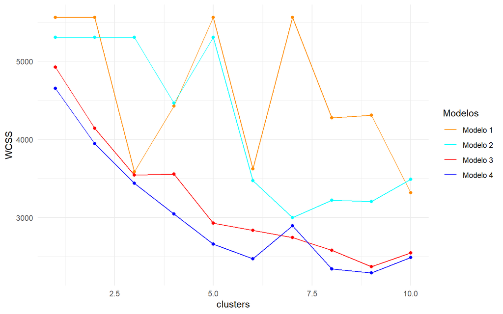

### Obtención del mejor modelo

Puesto lo anterior, se quedará solo con el modelo 4, al presentar mejores agrupaciones

```r
modelo <- mdl_4[,7:16]
cat_mdl <- mdl_4
```

### Acomodo de clusters

```r
clusters <- data.frame(kmeans = clus_mean[[1]],
                       kmedians = clus_median[[1]],
                       jerarquico = 0,
                       dbscan = 0,
                       gmm = 0,
                       som = 0,
                       spectral = 0,
                       teigen = 0,
                       meanshift = 0)
```

## Clustering Jerárquico

```r
clusters$jerarquico <- cutree(hclust(dist(modelo), method = "ward.D2"), k = 5)
table(clusters$jerarquico)
```

```
##
##   1   2   3   4   5
## 235 178 171  55   1
```

# Clusterización por medio de métodos externos a las clases

## DBSCAN

Hay que tomar un intervalo entero por discretización

```r
clusters$dbscan <- dbscan(modelo, eps = 1, minPts = 20)$cluster + 1
table(clusters$dbscan)
```

```
##
##   1   2   3   4   5
## 153 419  24  20  24
```

## GMM

```r
clusters$gmm <- Mclust(modelo)$classification
table(clusters$gmm)
```

```
##
##   1   2   3   4   5   6   7
##  76  26 225  70  29  27 187
```

## SOM

```r
clusters$som <- som(scale(modelo), somgrid(xdim = 3, ydim = 3, topo = "hexagonal"), rlen = 100)$unit.classif
table(clusters$som)
```

```
##
##   1   2   3   4   5   6   7   8   9
##   5  47  46  77  60 100 134 124  47
```

## Spectral Clustering

```r
clusters$spectral <- specc(as.matrix(modelo), centers = 5)
table(clusters$spectral)
```

```
##
##   1   2   3   4   5
## 151  70 120 195 104
```

## Modelos de mezcla no Gaussianos

```r
# 3 clusters es el máximo que converge
clusters$teigen <- teigen(modelo, Gs = 3)$classification
```

[output not shown]

```r
table(clusters$teigen )
```

```
##
##   1   2   3
##  56 515  69
```

## Mean Shift Clustering

```r
clusters$meanshift <- meanShift(scale(modelo), epsilonCluster = 2.5)$assignment[,1]
table(clusters$meanshift)
```

```
##
##   1   2   3   4   5
## 529  40  60   9   2
```

# Comparación de modelos

## Coeficiente de Silhouette

Se sitúa entre -1 y 1. Más alto mejor. Parece un índice de parsimonía

```r
silhouette <- sapply(1:9, function(x) mean(silhouette(clusters[,x], dist(modelo))[, 3]))
```

## Índice de Calinski-Harabasz

Más alto mejor

```r
cal_har <- sapply(1:9, function(x) intCriteria(as.matrix(modelo), as.integer(clusters[,x]), "Calinski_Harabasz")$calinski_harabasz)
```

## Índice de Davies-Bouldin

Más bajo es mejor

```r
dav_bou <- sapply(1:9, function(x) intCriteria(as.matrix(modelo), as.integer(clusters[,x]), "Davies_Bouldin")$davies_bouldin)
```

## Resumen estadísticas

```r
nclus <- sapply(1:9, function(x) max(clusters[,x]))
resumen <- data.frame(método = names(clusters),
                      clusters = nclus,
                      silhouette,
                      cal_har,
                      dav_bou)
resumen
```

```
##       método clusters  silhouette   cal_har  dav_bou
## 1     kmeans        5  0.22667718 123.94659 1.810637
## 2   kmedians        5 -0.07031188  86.55349 1.556155
## 3 jerarquico        5  0.19617423 171.65244 1.167912
## 4     dbscan        5  0.11451206  49.25579 1.663793
## 5        gmm        7  0.15317934  68.59909 2.482873
## 6        som        9  0.24586998 113.57257 1.477533
## 7   spectral        5  0.15765964 105.79607 1.751444
## 8     teigen        3  0.26243242  93.88190 1.319699
## 9  meanshift        5  0.31322985  76.44206 1.746621
```

## Elegir el método más adecuado

Se descartan por ser los peores: - gmm: por tener el tercero más alto - dbscan: por tener el segundo más bajo - kmedians: por tener el primero más bajo

```r
(resumen %>% slice(-c(2,4,5)))
```

```
##       método clusters silhouette   cal_har  dav_bou
## 1     kmeans        5  0.2266772 123.94659 1.810637
## 2 jerarquico        5  0.1961742 171.65244 1.167912
## 3        som        9  0.2458700 113.57257 1.477533
## 4   spectral        5  0.1576596 105.79607 1.751444
## 5     teigen        3  0.2624324  93.88190 1.319699
## 6  meanshift        5  0.3132298  76.44206 1.746621
```

Note que el jerárquico y meanshift ajustan de primeros en otras métricas, pero nos interesa una mejor elección en todas

```r
(resumen %>% slice(-c(1,2,4,5,9)))
```

```
##       método clusters silhouette  cal_har  dav_bou
## 1 jerarquico        5  0.1961742 171.6524 1.167912
## 2        som        9  0.2458700 113.5726 1.477533
## 3   spectral        5  0.1576596 105.7961 1.751444
## 4     teigen        3  0.2624324  93.8819 1.319699
```

# Modelo escogido

Por lo tanto, el modelo som, o Self Organizing Maps es el escogido ## Estadísticas breves

```r
set.seed(16)
som <- som(scale(modelo), somgrid(xdim = 3, ydim = 3, topo = "hexagonal"), rlen = 100)
(c_emotions <- sapply(1:9, function(x) colSums(cat_mdl[som$unit.classif == x,7:16])))
```

```
##              [,1] [,2] [,3] [,4] [,5] [,6] [,7] [,8] [,9]
## anger           3    2    4   16   37    2   10    8   57
## anticipation    5   31   81   75   17   10   13    9    5
## disgust         6    3    1   10   15    0    2    5   96
## fear            3   16    8   28   48   10   36   48   28
## joy             0   87   62    0    6    2    0    1    3
## sadness         2   12    7    6   21   12  105    9   56
## surprise        5    0   61    1   10    1    0   53    1
## trust         155   93   68    7    9   11    7    5    6
## negative        7   15   20   60   57   15  116   92  150
## positive      108  115  157   27   19   23   21    9   13
```

Defina los clusters: - 1. El cluster de confianza (155 y 108 positivo) - 2. El cluster de felicidad (50% de los datos) - 3. El cluster de espontaneidad (46% sorpresa, 40% felicidad y 30% anticipación) - 4. El cluster de la anticipación (30% anticipación sola) - 5. El cluster de la frustración (27% enojo, 21% miedo) - 6. El cluster de los mensajes largos (2 observaciones con mucho peso) - 7. El cluster de la tristeza (46% sadness) - 8. El cluster del miedo (40% sorpresa y 21% miedo) - 9. El cluster pesimista (40% anger, 70% disgust, 30% negative)

```r
round(c_emotions/rowSums(c_emotions),2)
```

```
##              [,1] [,2] [,3] [,4] [,5] [,6] [,7] [,8] [,9]
## anger        0.02 0.01 0.03 0.12 0.27 0.01 0.07 0.06 0.41
## anticipation 0.02 0.13 0.33 0.30 0.07 0.04 0.05 0.04 0.02
## disgust      0.04 0.02 0.01 0.07 0.11 0.00 0.01 0.04 0.70
## fear         0.01 0.07 0.04 0.12 0.21 0.04 0.16 0.21 0.12
## joy          0.00 0.54 0.39 0.00 0.04 0.01 0.00 0.01 0.02
## sadness      0.01 0.05 0.03 0.03 0.09 0.05 0.46 0.04 0.24
## surprise     0.04 0.00 0.46 0.01 0.08 0.01 0.00 0.40 0.01
## trust        0.43 0.26 0.19 0.02 0.02 0.03 0.02 0.01 0.02
## negative     0.01 0.03 0.04 0.11 0.11 0.03 0.22 0.17 0.28
## positive     0.22 0.23 0.32 0.05 0.04 0.05 0.04 0.02 0.03
```

```r
sapply(1:9, function(x) sum(som$unit.classif == x))
```

```
## [1] 135  79  59 129  22   2 100  48  66
```

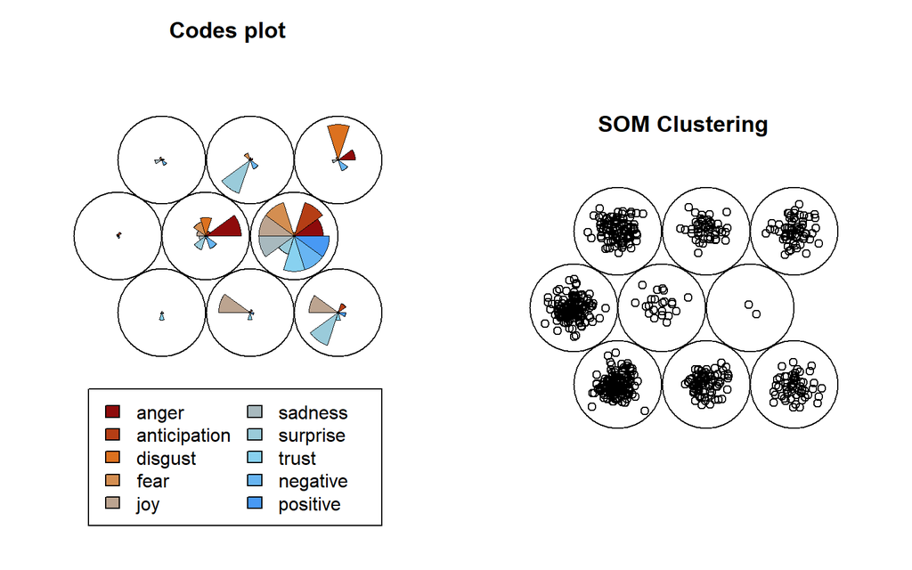

```r
#pdf("res/som_graficos.pdf", width = 10, height = 5)  # Puedes ajustar tamaño

par(mfrow = c(1, 2))
plot(som, palette.name = colorRampPalette(c("#8E0B0B","#E67E22","#B0B0B0", "#90D9F0", "#4899F4")))
plot(som, type = "mapping", main = "SOM Clustering")
```

```r
par(mfrow = c(1, 1))

# dev.off()
```

## Mensajes centroides

```r
centr <- sapply(1:9, function(x) sapply(1:10, function(y) median(modelo[som$unit.classif == x,y])))
```

```r
dist <- sapply(1:9, function(x)
  sapply(1:length(modelo[som$unit.classif == x,1]),
         function(y) sum((modelo[som$unit.classif == x,][y,] - centr[,x])^2)))
set.seed(15)
tomar <- sapply(1:9, function(x) sample(which(dist[[x]] == min(dist[[x]])),1))
```

```r
sapply(1:9, function(x) cat_mdl$mensaje[som$unit.classif == x][tomar[x]])
```

```
## [1] "ni idea la verdad"
## [2] "Dice Juanga que cuando programemos probablemente hace la clase virtual"
## [3] "Bueno, tsmpoco es que le iba a ser despiche"
## [4] "Ojalá llegar a ese level"
## [5] "pero es Introductoria, entonces por si la  quieren ver, ahí les roto"
## [6] "En vista de esto, desde el 2018 intenté promover en la Asamblea Legislativa la creación de un Colegio de Profesionales en Ciencias Actuariales, para asegurarnos de mantener la calidad y el nivel de la carrera, quitándole a la Escuela de Matemáticas la potestad de afectar la carrera tomando d…
## [7] "Pd: Lo estuve viendo y se ve muy bien!"
## [8] "El siguiente examen viene sin ser independientes"
## [9] "mentira"
```

## Proporción de cada autor en cada cluster

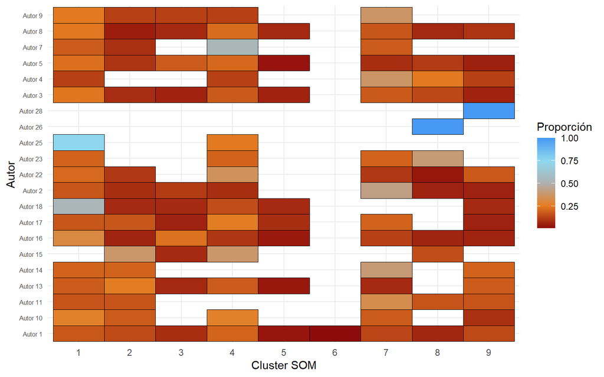

## Proporción de cada autor en su cluster dominante

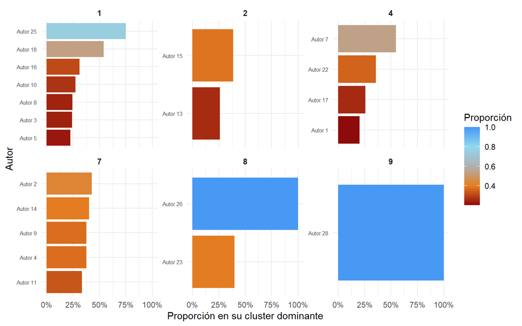